# Fit species distributions models

UK Centre for Ecology and Hydrology - DECIDE

# pieris_brassicae

### Load packages

```r
library(dplyr) # for data manipulation and %>%
library(raster) # for working with raster data
library(terra) # alternative to working with raster data that might be faster, used sporadically
library(randomForest) #for fitting random forest models
library(mgcv) # for fitting GAMs
library(dismo) # for fitting MAXENT models
library(ggplot2) # for plots
```

### Parameters

To be set up as parametrised markdown

```r
n_folds <- params$n_folds # how many folds for the cross validation
n_folds
```

```
## [1] 10
```

```r
species_name <- params$species_name # which species to model (scientific name, lowercase, underscore)
species_name
```

```
## [1] "pieris_brassicae"
```

```r
model_to_run <- params$model_to_run #which model to run: "glm","gam","rf","maxent"
model_to_run
```

```
## [1] "glm"
```

```r
plot_diagnostics <- params$plot_diagnostics #whether to produce diagnostic plots
plot_diagnostics
```

```
## [1] TRUE
```

```r
run_test <- params$run_test # whether this is a test run on smaller data
run_test
```

```
## [1] TRUE
```

### Load data

```r
#records and pseudoabsences
pas <- readRDS("data/derived_data/species/pas.RDS")

#species list
species_list <- readRDS("data/derived_data/species/species_list.RDS")

#environmental data
env_dat <- raster::stack("data/derived_data/environmental/envdata_fixedcoasts_nocorrs_100m_GB.gri")
#env_dat <- terra::rast(env_dat) # alternative approach not used


if(run_test){
  #crop the raster for testing
  smaller_extent <- extent(c(440000, 500000, 400000, 500000))
  env_dat <- crop(x = env_dat, y = smaller_extent)
}
```

### Preparing data

Combine the pres/pseudoabsence with the environmental data to make one data frame that we’ll be fitting models to.

This is where the number of pseudoabsenses relative to presences needs to be set

```r
prepare_data <- function(species_name, pas, env_data){



  #get the presence/absence for the relvant species
  pas_species <- pas[[species_name]]

  #if testing only get 20k of each from yorkshire(ish)
  if(run_test){
    pas_species$Presence <- pas_species$Presence %>% filter(lat < 500000,lat>400000,lon>440000, lon <500000) %>% as.data.frame()
    pas_species$pseudoAbsence <- pas_species$pseudoAbsence %>% filter(lat < 500000,lat>400000,lon>440000, lon <500000) %>% as.data.frame()

    #for testing purposes subset to 20000 rows
    if (nrow(pas_species$Presence) > 20000){
      pas_species$Presence <- pas_species$Presence[1:20000,] %>% as.data.frame()
    }
    if (nrow(pas_species$pseudoAbsence) > 20000){
      pas_species$pseudoAbsence <- pas_species$pseudoAbsence[1:20000,] %>% as.data.frame()
    }

  }



  #extract environmental variables
  env_data <- terra::rast(env_data)
  pres <- data.frame(val = 1,terra::extract(x = env_data, y = pas_species$Presence[,c("lon","lat")]), pas_species$Presence[,c("lon","lat")])
  ab <- data.frame(val = 0, terra::extract(x = env_data, y = pas_species$pseudoAbsence[,c("lon","lat")]), pas_species$pseudoAbsence[,c("lon","lat")])

  #remove NAs
  pres <- na.omit(pres)
  ab <- na.omit(ab)

  # make into one data frame
  pres_and_ab <- bind_rows(pres,ab)
  pres_and_ab
}

prepared_data <- prepare_data(species_name,pas,env_dat)

prepared_data %>% group_by(val) %>% summarise(n = n())
```

```
## # A tibble: 2 x 2
##     val     n
##   <dbl> <int>
## 1     0  4061
## 2     1  8118
```

Next, we define the folds in the data.

These folds are used in the bootstrapping and model assessment. By default we’re using 10 folds so we’ll fit 10 models which will train a unique set of 9 of those folds, and then will be assessed using the remaining fold. Folds are represented by a new column in the data which goes from `1:n_folds`

```r
fold_data <- function(prepared_data,n_folds=10){
  prepared_data$fold[prepared_data$val==1] <- prepared_data %>% filter(val == 1) %>% kfold(n_folds)
  prepared_data$fold[prepared_data$val==0] <- prepared_data %>% filter(val == 0) %>% kfold(n_folds)
  prepared_data
}

head(fold_data(prepared_data))
```

```
##   val ID broad_wood conif_wood arable impr_grass neutr_grass calc_grass acid_grass
## 1   1  1     100.00          0      0       0.00           0          0          0
## 2   1  2      31.25          0      0      62.50           0          0          0
## 3   1  3      56.25          0      0      43.75           0          0          0
## 4   1  4      87.50          0      0       6.25           0          0          0
## 5   1  5      87.50          0      0       6.25           0          0          0
## 6   1  6      75.00          0      0      25.00           0          0          0
##   fen_marsh_swamp heather heath_grass bog inland_rock saltwater freshwater
## 1               0       0           0   0           0         0       0.00
## 2               0       0           0   0           0         0       6.25
## 3               0       0           0   0           0         0       0.00
## 4               0       0           0   0           0         0       6.25
## 5               0       0           0   0           0         0       6.25
## 6               0       0           0   0           0         0       0.00
##   sup_lit_rock sup_lit_sed lit_rock lit_sed saltmarsh urban suburban
```

[output cut: 27 more lines]

```r
folded_data <- fold_data(prepared_data,n_folds)
```

Define a function that can determine weightings from data. If there are more presences than psuedoabsesnse then presences can be weighted down. This function determines those weights which can then be used as an argument in the model fitting function. If unbalanced number of records vs pseudo-absences the provide some weighting information. Used for GLM, RF and GAM.

```r
determine_weights <- function(folded_data,fold_i){
  n_records <- folded_data %>% filter(val == 1,fold != fold_i) %>% nrow()
  n_abs <- folded_data %>% filter(val == 0,fold != fold_i) %>% nrow()

  prop <- n_records / n_abs

  #if unbalanced
  if (n_records != n_abs){
    weights <- c(rep(1, n_records), rep(prop, n_abs))
  } else {
    weights <- NULL
  }

  weights
}

# if(run_test){
#   prepared_data %>% fold_data %>% determine_weights(1)
# }
```

### Fitting models

We currently fit four models.

Models:

- GLM (`base`?)
- GAM (`mgcv`)
- Random forest (`randomForest`)
- Maxent (`dismo`)

#### Maxent

Maxent models work best with equal number of presences and absences, so should match the number of presences and absences

```r
fit_maxent <- function(folded_data,fold_i){
  options(java.parameters = "-Xmx3g") #https://stackoverflow.com/questions/5374455/what-does-java-option-xmx-stand-for

  #fit the model
  mod <- maxent(x = folded_data %>% filter(fold != fold_i) %>% dplyr::select(-ID,-lat,-lon,-val,-fold),
                p = folded_data %>% filter(fold != fold_i) %>% dplyr::select(val)
                )

  #evaludate the model
  test_data <- folded_data %>% filter(fold == fold_i) %>% dplyr::select(-lat,-lon,-fold,-ID)
  evaluation <- dismo::evaluate(p = test_data %>% filter(val == 1),
                            a = test_data %>% filter(val == 0),
                            mod, tr = seq(0, 1, length.out = 200))

  #return the model + evaludation
  return(list(model = mod,evaluation = evaluation,summary = summary(mod)))
}

# if(model_to_run == "maxent" & run_test){
#   #test the function
#   test_mod1 <- fit_maxent(folded_data,1,env_dat)
#   class(test_mod1$model) #determine the class:
#   # [1] "MaxEnt"
#   # attr(,"package")
#   # [1] "dismo"
# }
```

#### GLM

Fit a GLM using `glm()`

```r
#from https://win-vector.com/2014/05/30/trimming-the-fat-from-glm-models-in-r/
clean_model = function(cm) {
  cm$y = c()
  cm$model = c()

  cm$residuals = c()
  cm$fitted.values = c()
  cm$effects = c()
  cm$qr$qr = c()
  cm$linear.predictors = c()
  cm$weights = c()
  cm$prior.weights = c()
  cm$data = c()
  cm
}

fit_glm <- function(folded_data,fold_i){

  weights <- determine_weights(folded_data,fold_i)
  train_data <- folded_data %>% filter(fold != fold_i) %>% dplyr::select(-lat,-lon,-fold,-ID)
  test_data <- folded_data %>% filter(fold == fold_i) %>% dplyr::select(-lat,-lon,-fold,-ID)

  mod <- glm(val ~ ., data = train_data,
                   family = binomial(link = "logit"),
                   weights = weights,
             model = F)

  evaluation <- dismo::evaluate(p = test_data %>% filter(val == 1),
                                  a = test_data %>% filter(val == 0),
                                  mod, tr = seq(0, 1, length.out = 200))
  mod_summary <- summary(mod)

  #currently not cleaning the model
  #mod <- clean_model(mod)

  #return the model + evaludation
  return(list(model = mod,evaluation = evaluation,summary = mod_summary))
}

# if(model_to_run == "glm" & run_test){
#   #test the function
#   test_mod2 <- fit_glm(folded_data,1)
#   class(test_mod2$model) #class:
#   # [1] "glm" "lm"
# }
```

#### Random forest

Fit a random forest with `randomForest` from package `randomForest`

```r
fit_rf <- function(folded_data,fold_i){
  weights <- determine_weights(folded_data,fold_i)
  if(!is.null(weights)){
    weights <- list(first(weights),last(weights))
  }

  train_data <- folded_data %>% filter(fold != fold_i) %>% dplyr::select(-lat,-lon,-fold,-ID)
  test_data <- folded_data %>% filter(fold == fold_i) %>% dplyr::select(-lat,-lon,-fold,-ID)

  mod <- randomForest(x = train_data %>% dplyr::select(-val),
                      y = train_data %>% dplyr::pull(val) %>% as.factor(),
                      importance = T,
                      norm.votes = TRUE)

  rf.pred <- predict(mod, type = "prob", newdata = test_data)[,2]
  evaluation <- dismo::evaluate(p = rf.pred[test_data$val == 1],
                                a = rf.pred[test_data$val == 0],
                                tr = seq(0, 1, length.out = 200))

  #return the model + evaluation
  return(list(model = mod,evaluation = evaluation,summary = summary(mod)))
}

# if(model_to_run == "rf" & run_test){
#   #test the function
#   test_mod3 <- fit_rf(folded_data,1)
#   class(test_mod3$model)
#   # [1] "randomForest"
# }
```

#### GAM

Fit a GAM using `gam` from package `mgcv`

```r
fit_gam <- function(folded_data,fold_i,knots_gam = -1){
  train_data <- folded_data %>% filter(fold != fold_i) %>% dplyr::select(-lat,-lon,-fold,-ID)
  test_data <- folded_data %>% filter(fold == fold_i) %>% dplyr::select(-lat,-lon,-fold,-ID)
  weights <- determine_weights(folded_data,fold_i)


  ## create formula for gam
  l <- sapply(folded_data %>% filter(fold != fold_i) %>% dplyr::select(-lon,-lat,-fold,-ID), unique)
  ks <- data.frame(variable = rownames(data.frame(k = round(sapply(l, length))[-1])),k = data.frame(k = round(sapply(l, length))[-1]))
  rownames(ks) <- 1:nrow(ks)

  # drop variables according to number of knots asked for
  # -1 is basically 9 knots
  if(knots_gam == -1) {
    v_keep <- ks[ks$k > 11,]
    print(paste("variable dropped =", ks$variable[!ks$variable %in% v_keep$variable]))
  }

  # any others just keep the variables with over the number of knots
  if(knots_gam > 0) {
    v_keep <- ks[ks$k > (knots_gam+3),]
    print(paste("variable dropped =", ks$variable[!ks$variable %in% v_keep$variable]))
  }

  #create the formula
  form <- as.formula(paste0("val ~ s(", paste(v_keep$variable,
                                            ", k = ", knots_gam) %>%
                            paste0(collapse = ") + s("), ")"))

  #fit the model
  mod <- gam(formula = form, data = train_data,
           family = binomial(link = 'logit'),
           select = TRUE, method = 'REML', gamma = 1.4,
           weights = weights)


  evaluation <- dismo::evaluate(p = test_data %>% filter(val == 1),
                                  a = test_data %>% filter(val == 0),
                                  mod, tr = seq(0, 1, length.out = 200))

  #return the model + evaludation
  return(list(model = mod,evaluation = evaluation,summary = summary(mod)))
}

# if(model_to_run == "gam" & run_test){
#   #test the function
#   test_mod4 <- fit_gam(folded_data,1)
#   class(test_mod4$model)
#   # [1] "gam" "glm" "lm"
# }
```

### Make predictions

This is where we apply the fitted models to predict across the entire environmental raster. We do this across each of the 10 bootstrapped models and get a mean prediction value. We also calculate the standard deviation of the 10 predictions which is part of the DECIDE score.

First define a function for making the predictions. It takes a list of the same type of model but fitted from each bootstrap of the data and the environmental raster `env_data`.

```r
#model list is a list of 10 models fitted from each bootstrap
get_predictions <- function(model_list,env_data) {
  #get the model class
  model_class <- class(model_list[[1]]$model)

  # number of bootstraps that were run
  k = length(model_list)

  # choose the type and index for predict function
  if("glm" %in% model_class){ #"glm" is in the model class for both gams and glms
    type <- "response"
    index <- NULL
  } else if ("randomForest" %in% model_class) {
    type <- "prob"
    index <- 2
  } else if ("MaxEnt" %in% model_class){
    type <- NULL
    index <- NULL
  }

  ## bootstrapped models

  # predict from each of the bootstrapped models and stack them together
  boots_out <- raster::stack(lapply(model_list, FUN = function(x) {predict(env_data, x$model, type=type, index=index)} ))

  ## quantiles
  mean_preds <- calc(boots_out, fun = mean, na.rm = T) # the mean
  rnge <- calc(boots_out, fun = function(x) {sd(x, na.rm = TRUE)}) # get the standard deviation
  # rnge <- quant_preds[[2]]-quant_preds[[1]] # get the range of max - min


  return(list(mean_predictions = mean_preds,
              quant_range = rnge))
}

#test
if(F){
  test <- get_predictions(list(test_mod1,test_mod1,test_mod1,test_mod1),env_dat)
}
```

Until this point we haven’t run any models, we have just defined functions for running them. This is where we fit the models and run predictions. We use `lapply` to run the model on each fold of the data at the same time.

```r
folds_list <- as.list(1:n_folds)

#run the models on the folded data
if(model_to_run == "glm"){

  mods <- lapply(folds_list,FUN = function(x){
    fit_glm(folded_data,x)
    })

} else if(model_to_run == "gam"){

  mods <- lapply(folds_list,FUN = function(x){
    fit_gam(folded_data,x)
    })

} else if(model_to_run == "rf"){

  mods <- lapply(folds_list,FUN = function(x){
    fit_rf(folded_data,x)
    })

} else if(model_to_run == "maxent"){

  mods <- lapply(folds_list,FUN = function(x){
    fit_maxent(folded_data,x)
    })

}
#get predictions
predictions <- get_predictions(mods,env_dat)
```

[output not shown]

[output cut: 64 more lines]

[output not shown]

```r
#checking model size
object.size(mods) %>% format(units = "Mb")
```

```
## [1] "123.7 Mb"
```

```r
object.size(predictions) %>% format(units = "Mb")
```

```
## [1] "9.2 Mb"
```

Model outputs for the first model

```r
#the model
#mods[[1]]$mod

#the evaluation by dismo
mods[[1]]$evaluation
```

```
## class          : ModelEvaluation
## n presences    : 812
## n absences     : 406
## AUC            : 0.7393227
## cor            : 0.3914838
## max TPR+TNR at : 0.1005025
```

```r
#the model summary
mods[[1]]$summary
```

```
##
## Call:
## glm(formula = val ~ ., family = binomial(link = "logit"), data = train_data,
##     weights = weights, model = F)
##
## Deviance Residuals:
##     Min       1Q   Median       3Q      Max
## -2.8384  -1.0888   0.7639   1.1370   2.6272
##
## Coefficients: (5 not defined because of singularities)
##                                      Estimate Std. Error z value Pr(>|z|)
## (Intercept)                         3.7067051  1.0539822   3.517 0.000437 ***
## broad_wood                         -0.0157567  0.0007813 -20.168  < 2e-16 ***
## conif_wood                         -0.0206276  0.0012816 -16.095  < 2e-16 ***
## arable                             -0.0137761  0.0006089 -22.624  < 2e-16 ***
## impr_grass                         -0.0135835  0.0006917 -19.637  < 2e-16 ***
## neutr_grass                        -0.0220033  0.0020539 -10.713  < 2e-16 ***
## calc_grass                         -0.0206849  0.0019747 -10.475  < 2e-16 ***
## acid_grass                         -0.0253344  0.0036436  -6.953 3.57e-12 ***
## fen_marsh_swamp                    -0.0036523  0.0151177  -0.242 0.809097
## heather                            -0.0336492  0.0027575 -12.203  < 2e-16 ***
## heath_grass                        -0.0263346  0.0015714 -16.759  < 2e-16 ***
## bog                                -0.0254887  0.0015721 -16.214  < 2e-16 ***
## inland_rock                        -0.0221960  0.0054117  -4.101 4.11e-05 ***
## saltwater                          -0.4306234 19.6956591  -0.022 0.982557
## freshwater                         -0.0113523  0.0014844  -7.648 2.05e-14 ***
## sup_lit_rock                               NA         NA      NA       NA
## sup_lit_sed                                NA         NA      NA       NA
## lit_rock                                   NA         NA      NA       NA
## lit_sed                                    NA         NA      NA       NA
## saltmarsh                          -0.9031042  8.6549667  -0.104 0.916895
## urban                              -0.0138399  0.0014135  -9.791  < 2e-16 ***
## suburban                                   NA         NA      NA       NA
## MeanTempColdQuarter                -0.1992098  0.1333635  -1.494 0.135245
## AnnualPrecip                        0.0229313  0.0038547   5.949 2.70e-09 ***
## PrecipWetMonth                      0.0702051  0.0089873   7.812 5.65e-15 ***
## PrecipDriestMonth                  -0.1057287  0.0149443  -7.075 1.50e-12 ***
## PrecipSeasonality                  -0.2039169  0.0325186  -6.271 3.59e-10 ***
## PrecipWettestQuarter               -0.0157332  0.0063465  -2.479 0.013173 *
## PrecipDriestQuarter                -0.0099093  0.0088100  -1.125 0.260685
## PrecipWarmQuarter                  -0.0122825  0.0044698  -2.748 0.005999 **
## PrecipColdQuarter                  -0.0487164  0.0066155  -7.364 1.79e-13 ***
## elevation_map_coasts_fixed_GB_100m -0.0059568  0.0008993  -6.624 3.50e-11 ***
## slope                              -0.0251932  0.0092717  -2.717 0.006583 **
## aspect                              0.0003234  0.0001869   1.730 0.083580 .
## ---
## Signif. codes:  0 '***' 0.001 '**' 0.01 '*' 0.05 '.' 0.1 ' ' 1
##
## (Dispersion parameter for binomial family taken to be 1)
##
##     Null deviance: 20257  on 10960  degrees of freedom
## Residual deviance: 17502  on 10932  degrees of freedom
## AIC: 17565
##
## Number of Fisher Scoring iterations: 13
```

```r
#model AUCs
sapply(mods, function(x) {slot(x$evaluation, "auc")})
```

```
##  [1] 0.7393227 0.7356676 0.7340114 0.7461629 0.7286940 0.7470014 0.7245414 0.7181306
##  [9] 0.7522143 0.7421225
```

### Save outputs

Now that we’ve run the models we need to save the outputs.

The outputs are saved in their corresponding folder in `data/derived_data/model_outputs_by_species` where there are 4 folders for each model type: `gam`, `glm`, `maxent`, `rf`. There is also an `ensemble` folder but that is filled in the next stage.

For each model run for each species we end up with 4 files

- `mean_predictions_[SPECIES].grd/gri` is the mean predictions
- `bootstrapped_sd_[SPECIES].grd/gri` is the standard deviation between each bootstrapped model prediction
- `mean_AUC_[SPECIES].rds` is the mean AUC for that model/species combo stored as a single numeric value
- `models_[SPECIES].rds` contains one of the models, the AUCs from each model, the mean AUC across all models (again) and the summaries for all models.

```r
#save rasters
#write prediction
raster::writeRaster(predictions$mean_predictions,filename = paste0("data/derived_data/model_outputs_by_species/",model_to_run,"/mean_prediction_",species_name,".grd"),overwrite=T)
```

```
## class      : RasterLayer
## dimensions : 1000, 600, 6e+05  (nrow, ncol, ncell)
## resolution : 100, 100  (x, y)
## extent     : 440000, 5e+05, 4e+05, 5e+05  (xmin, xmax, ymin, ymax)
## crs        : +proj=tmerc +lat_0=49 +lon_0=-2 +k=0.9996012717 +x_0=400000 +y_0=-100000 +ellps=airy +units=m +no_defs
## source     : mean_prediction_pieris_brassicae.grd
## names      : layer
## values     : 2.220446e-16, 0.8854555  (min, max)
```

```r
#write SDM uncertainty
raster::writeRaster(predictions$quant_range,filename = paste0("data/derived_data/model_outputs_by_species/",model_to_run,"/bootstrapped_sd_",species_name,".grd"),overwrite=T)
```

```
## class      : RasterLayer
## dimensions : 1000, 600, 6e+05  (nrow, ncol, ncell)
## resolution : 100, 100  (x, y)
## extent     : 440000, 5e+05, 4e+05, 5e+05  (xmin, xmax, ymin, ymax)
## crs        : +proj=tmerc +lat_0=49 +lon_0=-2 +k=0.9996012717 +x_0=400000 +y_0=-100000 +ellps=airy +units=m +no_defs
## source     : bootstrapped_sd_pieris_brassicae.grd
## names      : layer
## values     : 0, 0.1308764  (min, max)
```

```r
#save model info
#calculate mean AUC across all models, and generate summaries
AUCs <- sapply(mods, function(x) {slot(x$evaluation, "auc")})
mean_AUC <- AUCs %>% mean()
summaries <- lapply(mods,FUN = function(x){x$summary})

#remove the models for all but the first bootstrap
#but retain evaluations and summaries
for (i in 2:n_folds){
  mods[[i]]$model <- NULL
}

#check model size
object.size(mods) %>% format(units = "Mb")
```

```
## [1] "22.2 Mb"
```

```r
object.size(summaries) %>% format(units = "Mb")
```

```
## [1] "9.8 Mb"
```

```r
#create one object for saving
output <-
  list(mods,
       AUCs = AUCs,
       mean_AUC = mean_AUC,
       summaries = summaries)

#check size of this object
object.size(output) %>% format(units = "Mb") # all models
```

```
## [1] "32 Mb"
```

```r
#save output
saveRDS(output,file = paste0("data/derived_data/model_outputs_by_species/",model_to_run,"/models_",species_name,".rds"))

#also write AUCs elsewhere so that in order to determine which models to include in the ensemble we don't have to load in the full model object.
saveRDS(mean_AUC, file = paste0("data/derived_data/model_outputs_by_species/",model_to_run,"/mean_AUC_",species_name,".rds"))
```

### Diagnostic plots

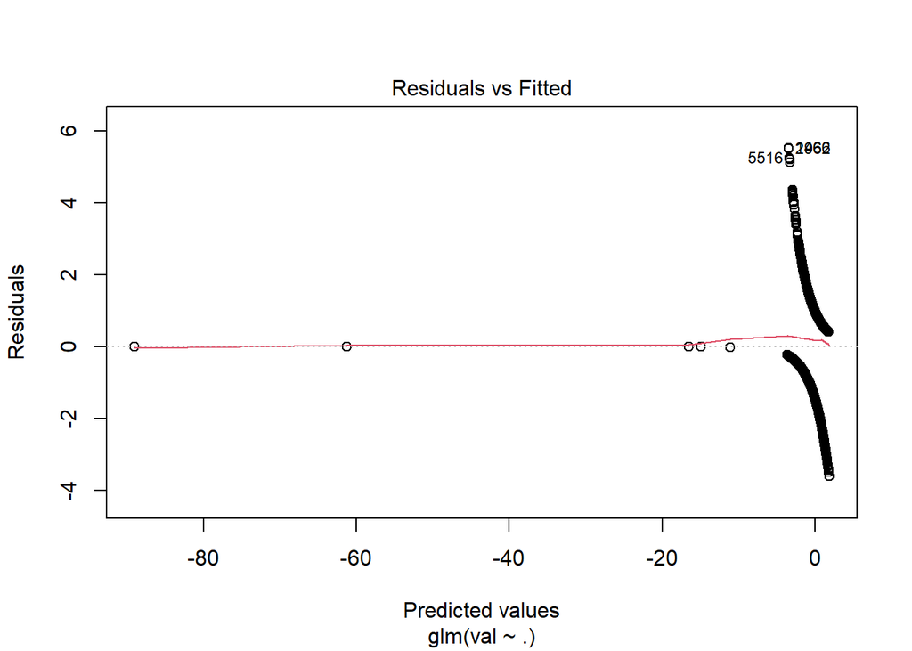

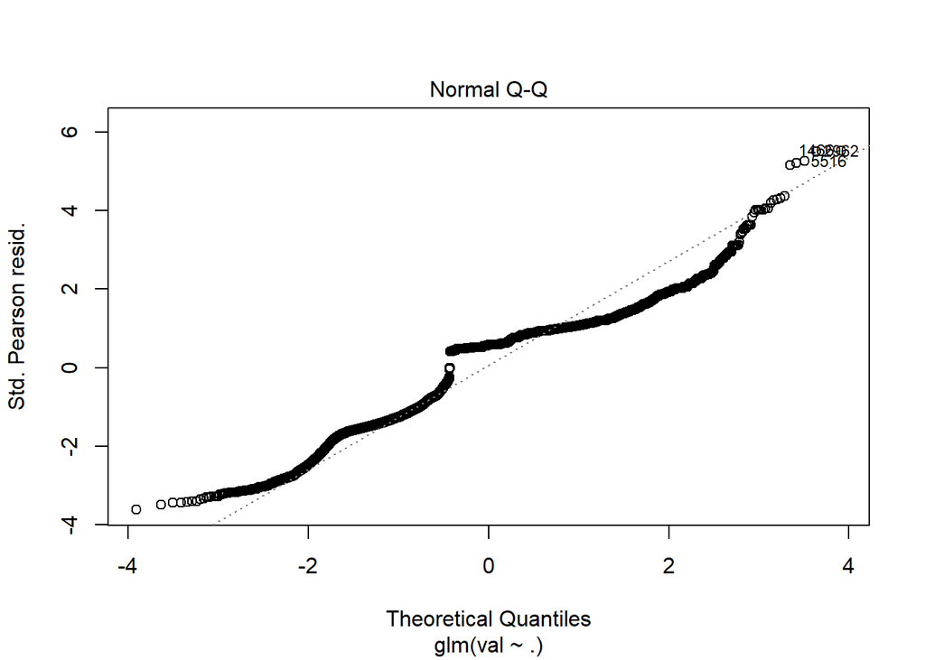

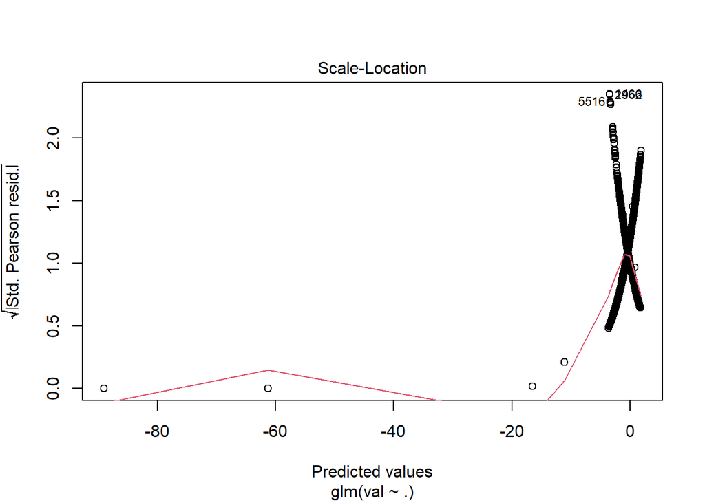

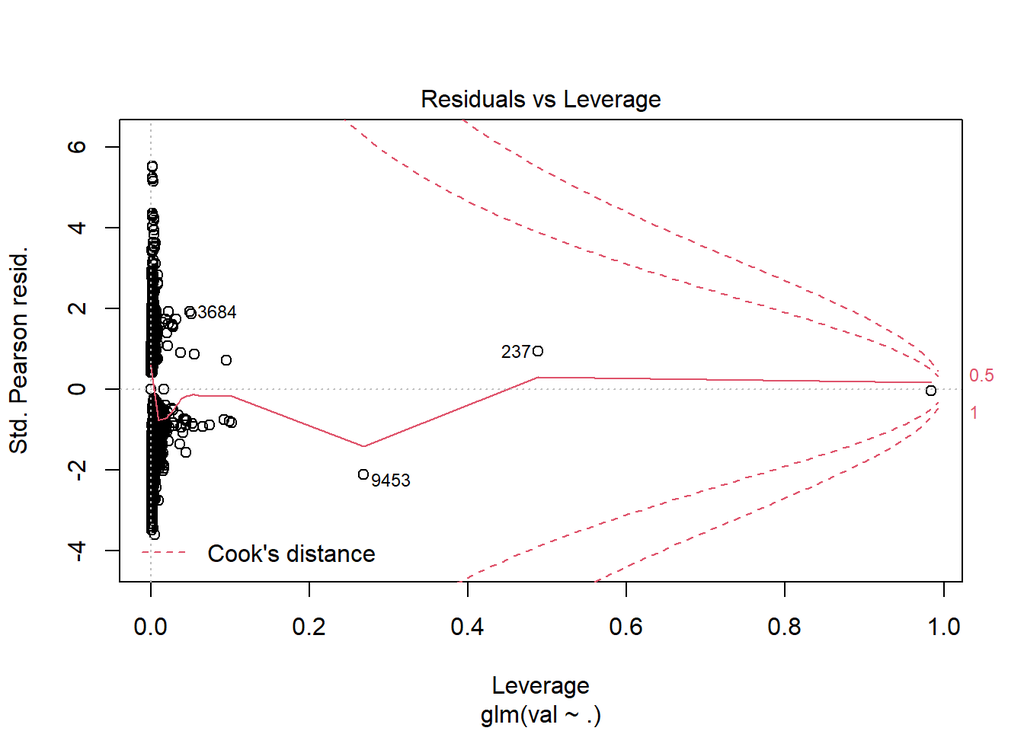

```r
if(plot_diagnostics){
  plot(mods[[1]]$model)
}
```

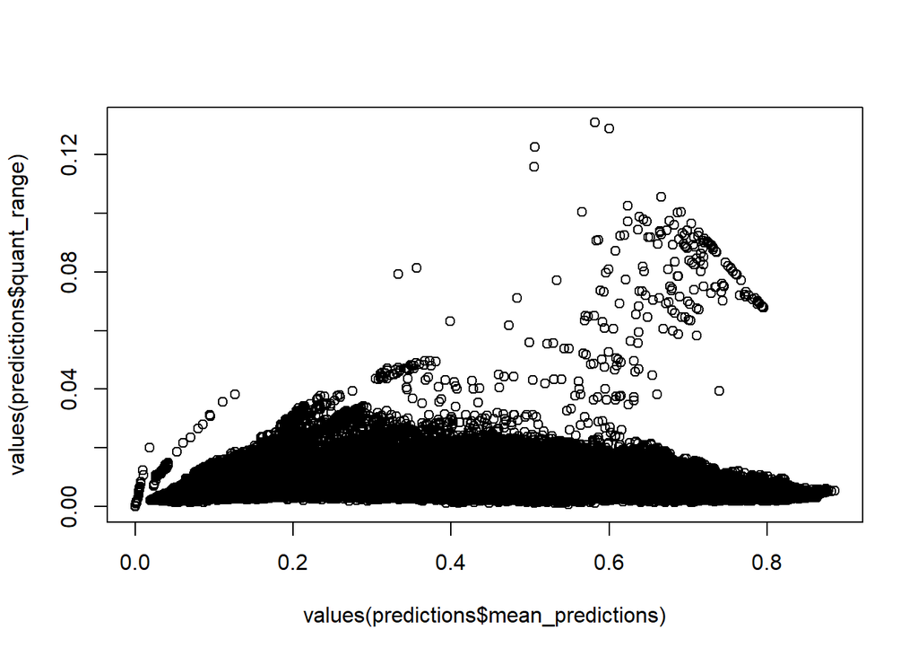

```r
#mean prediction versus sd
plot(x = values(predictions$mean_predictions),y = values(predictions$quant_range))
```

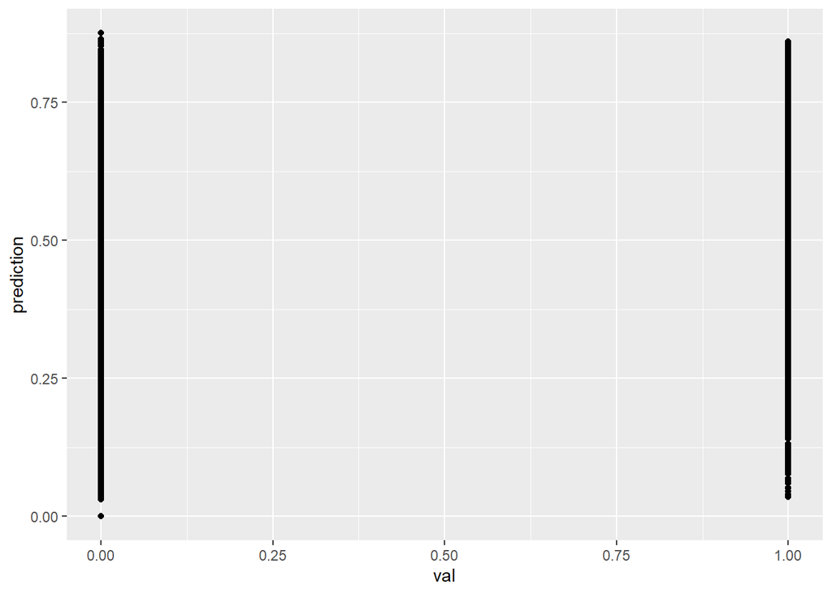

```r
#compare predicted vs actual (and pseudo)
test <- data.frame(folded_data[,c("lon","lat","val")],prediction =terra::extract(x = predictions$mean_predictions, y = folded_data[,c("lon","lat")])) %>% na.omit(test)

test %>%
  ggplot(aes(x = val, y = prediction))+
  geom_point()
```

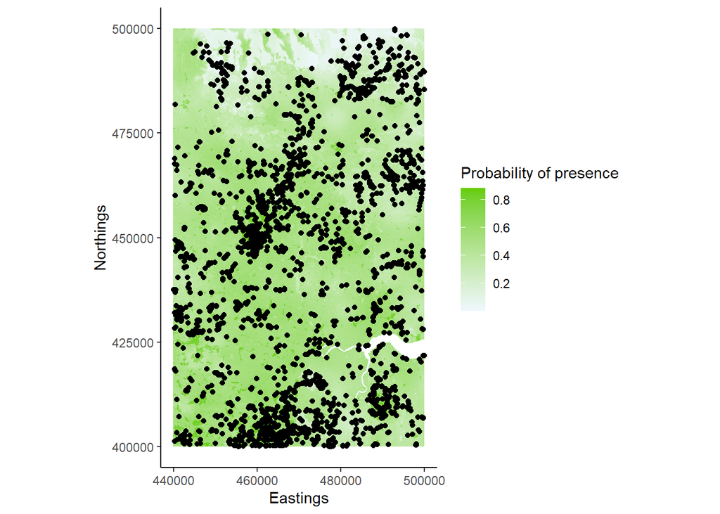

```r
#turn raster into a data frame for ggplotting
test_spdf <- as(predictions$mean_predictions, "SpatialPixelsDataFrame")
test_df <- as.data.frame(test_spdf)
colnames(test_df) <- c("value", "x", "y")

#plot raster and points
test %>%
  filter(val == 1) %>%
  ggplot(aes(x = lon,y = lat))+
  geom_tile(data=test_df, aes(x=x, y=y, fill=value), alpha=1)+
  scale_fill_gradient(low = "aliceblue",high = "chartreuse3")+
  geom_point(alpha = 1,shape = 16)+
  theme_classic()+
  labs(fill = "Probability of presence",x = "Eastings",y = "Northings")+
  coord_fixed()
```

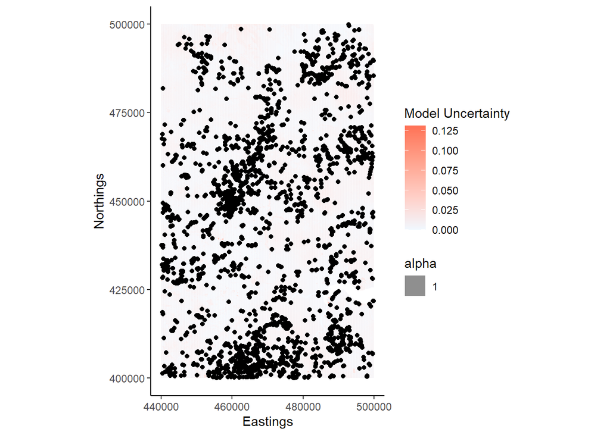

```r
#turn raster into a data frame for ggplotting
test_spdf <- as(predictions$quant_range, "SpatialPixelsDataFrame")
test_df <- as.data.frame(test_spdf)
colnames(test_df) <- c("value", "x", "y")

#plot raster and points
test %>%
  filter(val == 1) %>%
  ggplot(aes(x = lon,y = lat))+
  geom_tile(data=test_df, aes(x=x, y=y, fill=value, alpha=1))+
  scale_fill_gradient(low = "aliceblue",high = "coral1")+
  geom_point(alpha = 1,shape = 16)+
  theme_classic()+
  labs(fill = "Model Uncertainty",x = "Eastings",y = "Northings")+
  coord_fixed()
```